# Data Normalization

Kelly Stratton, Lisa Bramer

2022-08-08

## Overview

There are two general types of normalization approaches included in `pmartR`:

1. Instrument normalization - applicable to labeled proteomics data and (sometimes) NMR data
2. Statistical normalization - applicable to all of the data types supported in `pmartR`, with RNAseq data being a special case

When instrument normalization is required, this is done after quality control (filtering) and prior to statistical normalization.

## Instrument Normalization

### Labeled Proteomics

Labeled proteomics data, such as that generated via TMT (tandem mass tag) or iTRAQ (isobaric tags for relative quantification), involves running subsets of samples from an experiment on separate “plexes” or “plates” or “experiments”. Each plex includes a “reference pool” sample, consisting of a pool of all of the experimental samples. (Note that the assignment of samples to a plex is a key part of the randomization and experimental design processes, due to the way data goes missing when these labeled methods are utilized.) Samples must be normalized to their corresponding reference pool in order to enable comparisons between samples.

#### Usage

When working with labeled proteomics data, an `isobaricpepData` object should be used. To perform the reference pool normalization, use the `normalize_isobaric()` function.

There are two ways to specify the information needed for identifying reference samples which should be used for normalization:

1. Specify the `channel_cname` and `refpool_channel`. This should be used when the reference sample for each plex/plate/experiment was always located in the same channel. Here `channel_cname` gives the column name for the column in `f_data` which gives information about which channel each sample was run on, and `refpool_channel` is a character string specifying the value in `channel_colname` that corresponds to the reference sample channel.
2. Specify the `refpool_cname` and `refpool_notation`. This should be used when the reference sample is not in a consistent channel across experiments/plates. Here, `refpool_cname` gives the name of the column in `f_data` which indicates whether a sample is a reference or not, and `refpool_notation` is a character string giving the value used to denote a reference sample in that column. } In both cases you must specify `exp_cname` which gives the column name for the column in `f_data` containing information about which plex/plate/experiment a sample was run on.

### NMR

In order to ensure that samples are comparable to one another, normalizing NMR data to either a sample-specific property (such as sample mass) or to a spiked-in reference standard.

#### Usage

There are two ways to specify the information needed for performing instrument normalization on an nmrData object:

1. Specify `sample_property_cname`. This should be used when normalizing to a sample property, such as sample concentration or mass, is desired. Here, `sample_property_cname` gives the name of the column in `f_data` which contains the property to use for normalization. If any samples have a missing value for this column, and error is returned.
2. Specify `metabolite_name`. This should be used when normalization to a spiked in standard is desired. Here `metabolite_name` gives the name of the metabolite in e_data (and e_meta, if present) corresponding to the spiked in standard. If any samples have a missing value for this metabolite, an error is returned.

The option to backtransform the data after either of these NMR normalizations is offered, if the user would like to ensure values are on a scale similar to their raw values before normalization. The following values are calculated and/or applied for backtransformation purposes:

- If normalization using a metabolite in `e_data` is specified, the location parameter is the median of the values for `metabolite_name`
- If normalization using a sample property in `f_data` is specified, the location parameter is the median of the values in `sample_property`

We’ll use the example NMR dataset from the `pmartRdata` package.

```r
data(nmr_object_identified)
summary(nmr_object_identified)
```

| Class | nmrData |
| --- | --- |
| Unique SampleIDs (f_data) | 41 |
| Unique Metabolites (e_data) | 38 |
| Unique Metabolites (e_meta) | 38 |
| Missing Observations | 0 |
| Proportion Missing | 0 |

```r
# log2 transform the values
nmr_object <- edata_transform(nmr_object_identified, "log2")
```

**Normalize using property of each sample**

We can first create a normRes object and explore the values of the sample property to be used for instrument normalization. The figure below shows the Concentration values for each sample.

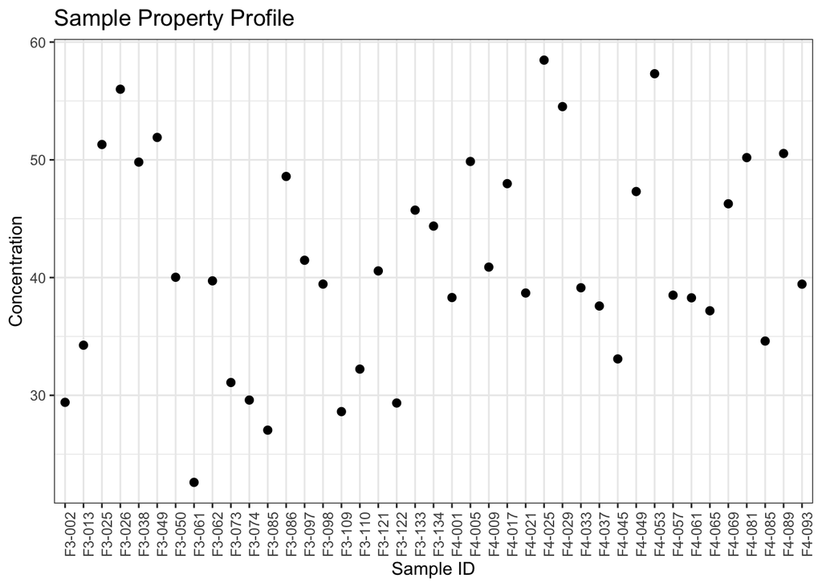

```r
# don't apply the normalization yet
normRes_property <-
  normalize_nmr(nmr_object,
                apply_norm = FALSE,
                sample_property_cname = "Concentration")
plot(normRes_property)
```

If we are satisified with using these Concentration values for normalization, we can apply the instrument normalization and plot the resulting omicsData object.

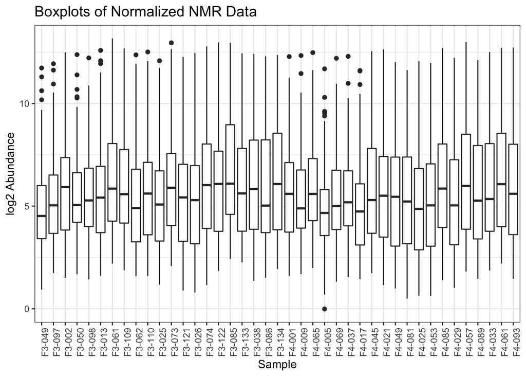

```r
# now apply the normalization
nmr_norm_property <-
  normalize_nmr(nmr_object,
                apply_norm = TRUE,
                sample_property_cname = "Concentration",
                backtransform = TRUE)
plot(nmr_norm_property)
```

**Normalize using reference metabolite**

We can first create a normRes object and explore the values of the reference metabolite to be used for instrument normalization. The figure below shows the log2 values of the reference metabolite for each sample.

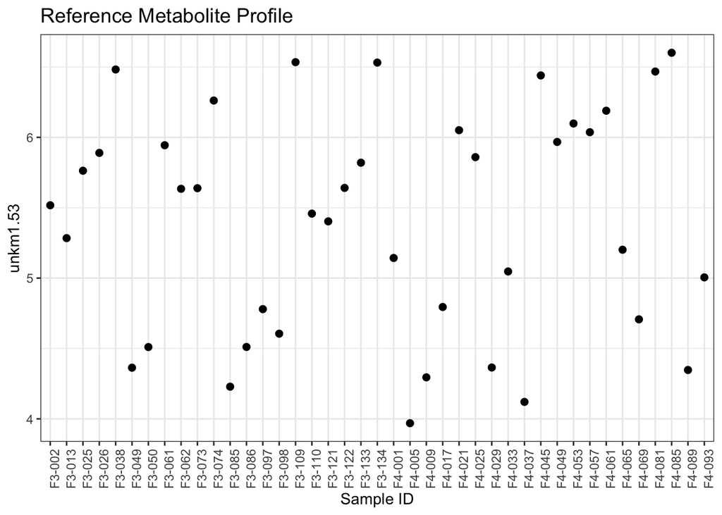

```r
# don't apply the normalization yet
normRes_reference <-
  normalize_nmr(nmr_object,
                apply_norm = FALSE,
                metabolite_name = "unkm1.53")
plot(normRes_reference)
```

If we are satisified with using these values for normalization, we can apply the instrument normalization and plot the resulting omicsData object.

```r
# now apply the normalization
nmr_norm_reference <- normalize_nmr(nmr_object,
                                    apply_norm = TRUE,
                                    metabolite_name = "unkm1.53")
```

```
## backtransform is set to FALSE. Examine the distribution of your data to ensure this is reasonable.
```

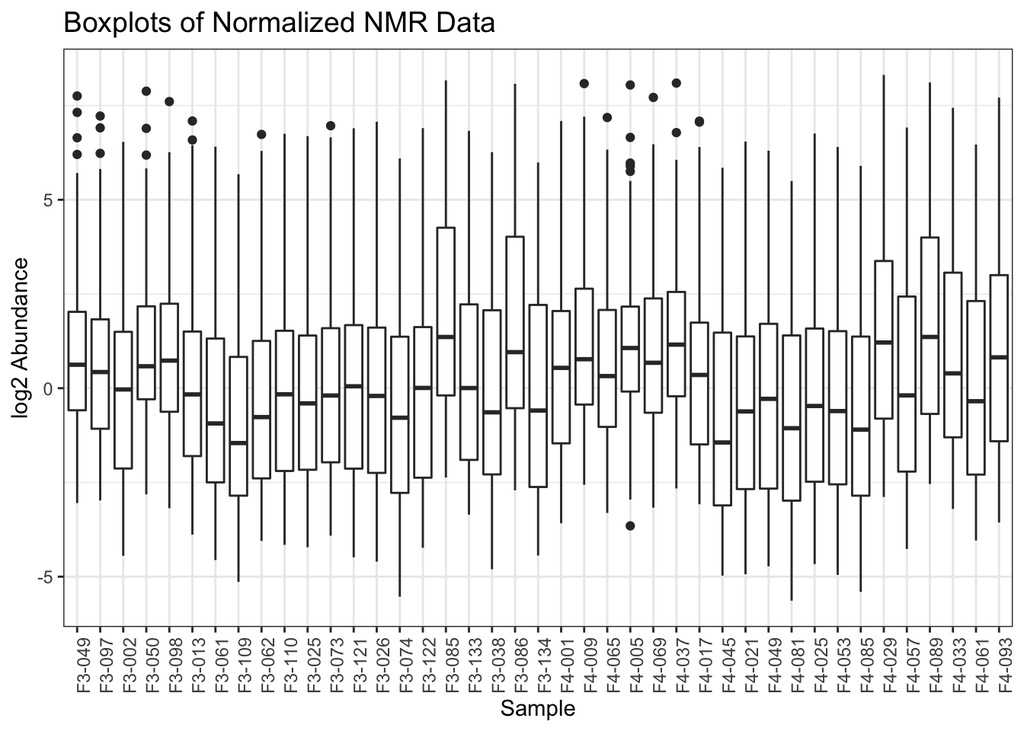

```r
plot(nmr_norm_reference)
```